# Numerical differentiation applied to BVPs

TMA4130 Autumn 2022

```python
import numpy as np
import matplotlib.pyplot as plt
from numpy.linalg import solve, norm
import math
```

## Boundary value problem

We want to use finite differences to find a numerical solution to the boundary value problem \begin{align*} a u''(x) - vu'(x) - \kappa u(x) &= 0\, , \ \ x\in (0,L)\, \\ u(0) &= u_0\, ,\\ u(L) &= u_L\, , \end{align*} where $v$, $\alpha$ and $\kappa$ are known positive constants. Let us begin by defining the coefficient matrices coming from discretising the diffusion, convection and reaction terms:

```python
def CoeffMatrices(n,h):
    """
        CoeffMatrices(n)

    Builds the finite difference coefficient matrices for u(x), u'(x) and u''(x)

    Input:
        n - number of nodes (including the boundary ones)
        h - mesh size
    Output:
        D  - the n-by-n central diffusion matrix
        Cc - the n-by-n central convection matrix
        Cf - the n-by-n forward convection matrix
        R  - the n-by-n reaction matrix
    """
    D = np.zeros((n,n)) #starts (central) diffusion matrix as an n-by-n zero matrix
    Cc = np.zeros((n,n)) #start central convection matrix as an n-by-n zero matrix
    Cf = np.zeros((n,n)) #start forward convection as an n-by-n zero matrix
    R = np.zeros((n,n)) #start reaction matrix as an n-by-n zero matrix

    #Compute non-zero entries
    for i in range(1,n-1,1):

        D[i,i-1] = 1/h**2
        D[i,i] = -2/h**2
        D[i,i+1] = 1/h**2

        Cc[i,i-1] = -1/(2*h)
        Cc[i,i+1] = 1/(2*h)

        Cf[i,i-1] = -1/h
        Cf[i,i] = 1/h

        R[i,i] = 1

    return D, Cc, Cf, R
```

## Solving the linear system

After assembling the final coefficient matrix, we have a linear system to solve. But before solving it, we need to apply the boundary conditions. To do that, we replace the first and last rows in the system by the equations \begin{align*} &1\cdot U_0 + 0\cdot U_1 + 0\cdot U_2 \, + \, ... \, +\, 0\cdot U_{n+1} = u_0 \, \\ &0\cdot U_0 + 0\cdot U_1 \, + \, ... \, +\, 0\cdot U_{n-1} +1\cdot U_{n+1} = u_L \, . \end{align*} After solving the system, we compute and print the approximation error: \begin{align*} \varepsilon = \mathrm{max}_{i=1,...,N}|U_i-u(x_i)|\, . \end{align*}

```python
def solveSystem(K,u0,uL):
    """
        solveSystem(n)

    Applies the boundary conditions and solves the linear system

    Input:
        K  - coefficient matrix
        u0 - left boundary condition
        uL - right boundary condition
    Output:
        u - n-1 array containing the numerical solution u_i at each node i
        x - n-1 array containing the nodel coordinates x_i
    """
    n = np.shape(K)[0] #find the number of nodes
    f = np.zeros((n,1)) #fill the right-hand side vector f with zeros only
    x = np.linspace(0,L,n) #nodal points
    x = x.reshape(n,1) #turn x into a column vector

    #Apply boundary conditions
    K[0,0] = 1
    K[n-1,n-1] = 1
    f[0] = u0
    f[n-1] = uL

    #Solve the linear system
    U = solve(K,f)

    return U, x
```

## Problem setup and numerical solution

We now prescribe the problem data (equation coefficients, interval length and boundary conditions) and the number $n$ of nodes in the discrete interval. Then we compute the total coefficient matrix and solve the linear system:

```
0.01573974642568632
```

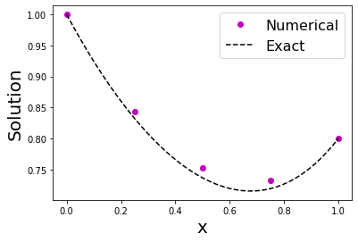

```python
#Equation parameters
a = 1; v = 1; k = 2

#Interval length and boundary conditions
L = 1; u0 = 1; uL = .8

#Discretisation
n = 5 #total number of nodes (including boundary nodes)
h = L/(n-1) #mesh size

#Compute the coefficient terms stemming from the different terms in the equation
D, Cc, Cf, R = CoeffMatrices(n,h)
C = Cf #choose to take the convection matrix C as either the central (Cc) or the forward (Cf) one
K = a*D - v*C - k*R #computes total coefficient matrix
#print(K)

#Solve the linear system and compute error (using known exact solution for u0=L=k=2v=2a=2)
U, x = solveSystem(K,u0,uL)
c2 = (uL-np.exp(-1))/(np.exp(2)-np.exp(-1))
c1 = 1-c2
u = c1*np.exp(-x)+c2*np.exp(2*x)
print(np.max(abs(U-u))) #maximum nodal error

#Plot exact and numberical solutions
plt.plot(x,U,'om')
x = np.linspace(0,L,1000);
plt.plot(x,c1*np.exp(-x)+c2*np.exp(2*x),'--k')

#Axis and legend for the plots
plt.legend(['Numerical', 'Exact'], fontsize = 16)
plt.xlabel('x', fontsize = 20)
plt.ylabel('Solution', fontsize = 20)
plt.rcParams['figure.figsize'] = [15, 6]
```